# Group4-KKT,KYJ,KYR,SJH

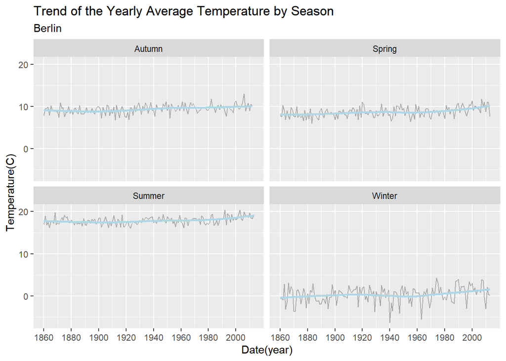

```r
city %>% group_by(season, year) %>% summarise(ave = mean(AverageTemperature)) %>% na.omit() %>%
  ggplot() + geom_line(col="dark grey") + aes(x=year, y=ave) + geom_smooth(col='light blue', se=F)+
  labs(title = "Trend of the Yearly Average Temperature by Season", subtitle="Berlin", x= "Date(year)", y="Temperature(C)")+
  scale_x_continuous(breaks = seq(1860, 2013, 20))+
  facet_wrap(~season)
```

```r
#The difference between the highest and lowest is 3.98 degrees, and it has increased by about 2 degrees over the period we surveyed. In 1848, railways were built, and industrialization was carried out. It underwent a rapid industrialization process since the mid-19th century. Industrialization itself was highly deviated by region, but in the late 19th century, the proportion of industrial population in the entire population increased rapidly. Moreover, textiles and leather industries, which are traditional industries, were relatively stagnant, while in new industries such as coal, steel, chemicals and electricity, rapid growth was repeated along with the introduction and spread of modern production organizations. During the period 1873-1900, the number of modern factory workers surged from 1.8 million to 5.7 million, exceeding 60 percent of the total industrial population. At the same time, the centralization phenomenon of large companies leading production was noticeable. The industrial population began to explode in 1880, and temperatures have been rising since 1880.
```

#3-3 London

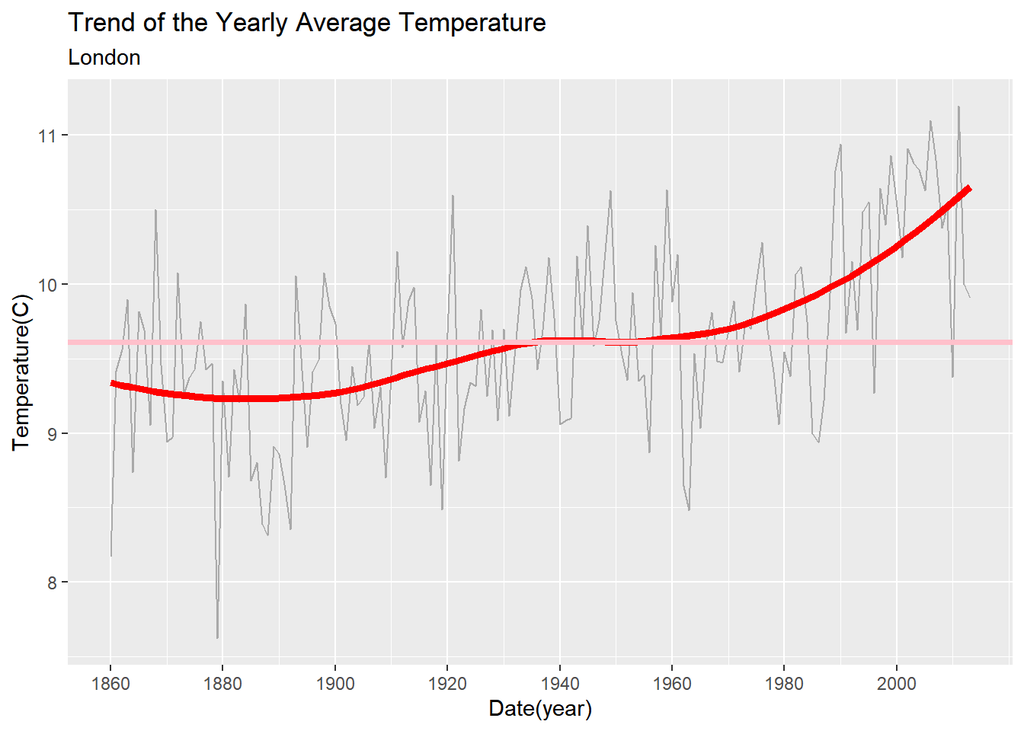

```r
#Jaehyun Song

city <- yclean %>% filter(City=="London") %>% na.omit()

city %>% group_by(year) %>% summarise(ave = mean(AverageTemperature)) %>% na.omit() %>%
  ggplot() + geom_line(col="dark grey") + aes(x=year, y=ave) + geom_smooth(col='Red', se=F, lwd=1.7)+
  geom_hline(yintercept=mean(city$AverageTemperature), col='pink', lwd=1.3)+
  labs(title = "Trend of the Yearly Average Temperature", subtitle="London", x= "Date(year)", y="Temperature(C)")+
  scale_x_continuous(breaks = seq(1860, 2013, 20))
```

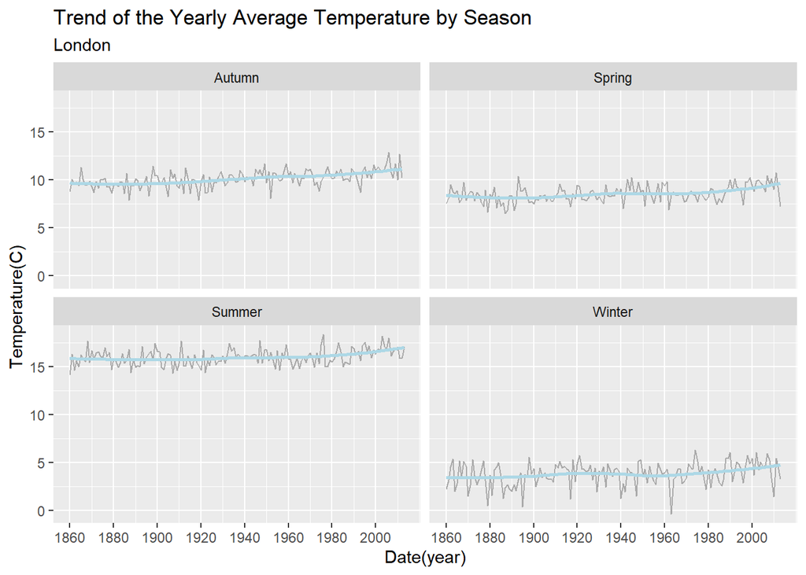

```r
city %>% group_by(season, year) %>% summarise(ave = mean(AverageTemperature)) %>% na.omit() %>%
  ggplot() + geom_line(col="dark grey") + aes(x=year, y=ave) + geom_smooth(col='light blue', se=F)+
  labs(title = "Trend of the Yearly Average Temperature by Season", subtitle="London", x= "Date(year)", y="Temperature(C)")+
  scale_x_continuous(breaks = seq(1860, 2013, 20))+
  facet_wrap(~season)
```

```r
#Compared to peak and lowest, there is a 3.57 degree difference and an increase of about 1.5 degrees over the period we investigated period. As in all parts of Europe, temperatures have changed significantly since World War II.
```

# EU-Cities that change of the temperature is not significant

#3-4 Rome

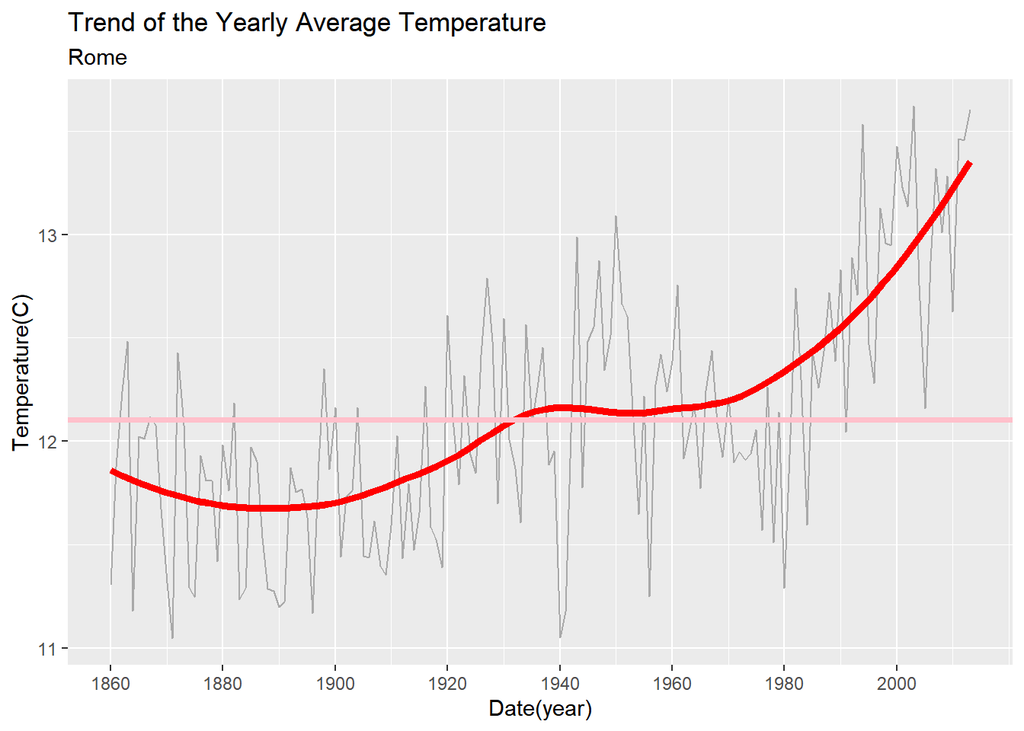

```r
#Jaehyun Song

city <- yclean %>% filter(City=="Rome") %>% na.omit()

city %>% group_by(year) %>% summarise(ave = mean(AverageTemperature)) %>% na.omit() %>%
  ggplot() + geom_line(col="dark grey") + aes(x=year, y=ave) + geom_smooth(col='Red', se=F, lwd=1.7)+
  geom_hline(yintercept=mean(city$AverageTemperature), col='pink', lwd=1.3)+
  labs(title = "Trend of the Yearly Average Temperature", subtitle="Rome", x= "Date(year)", y="Temperature(C)")+
  scale_x_continuous(breaks = seq(1860, 2013, 20))
```

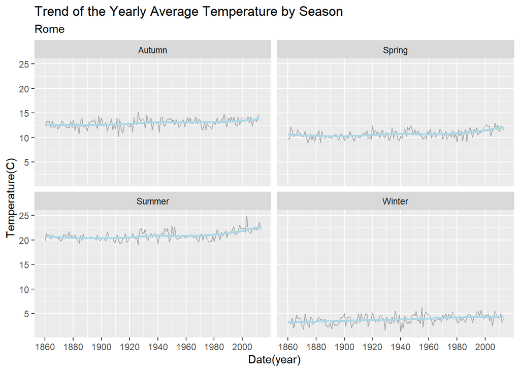

```r
city %>% group_by(season, year) %>% summarise(ave = mean(AverageTemperature)) %>% na.omit() %>%
  ggplot() + geom_line(col="dark grey") + aes(x=year, y=ave) + geom_smooth(col='light blue', se=F)+
  labs(title = "Trend of the Yearly Average Temperature by Season", subtitle="Rome", x= "Date(year)", y="Temperature(C)")+
  scale_x_continuous(breaks = seq(1860, 2013, 20))+
  facet_wrap(~season)
```

```r
#There was a difference of 2.57 degrees between the highest and lowest prices, and during the period, the graph looked steep but rose by 1 degree. Rome did not have a distinct industrial development.
```

#3-5 Madrid

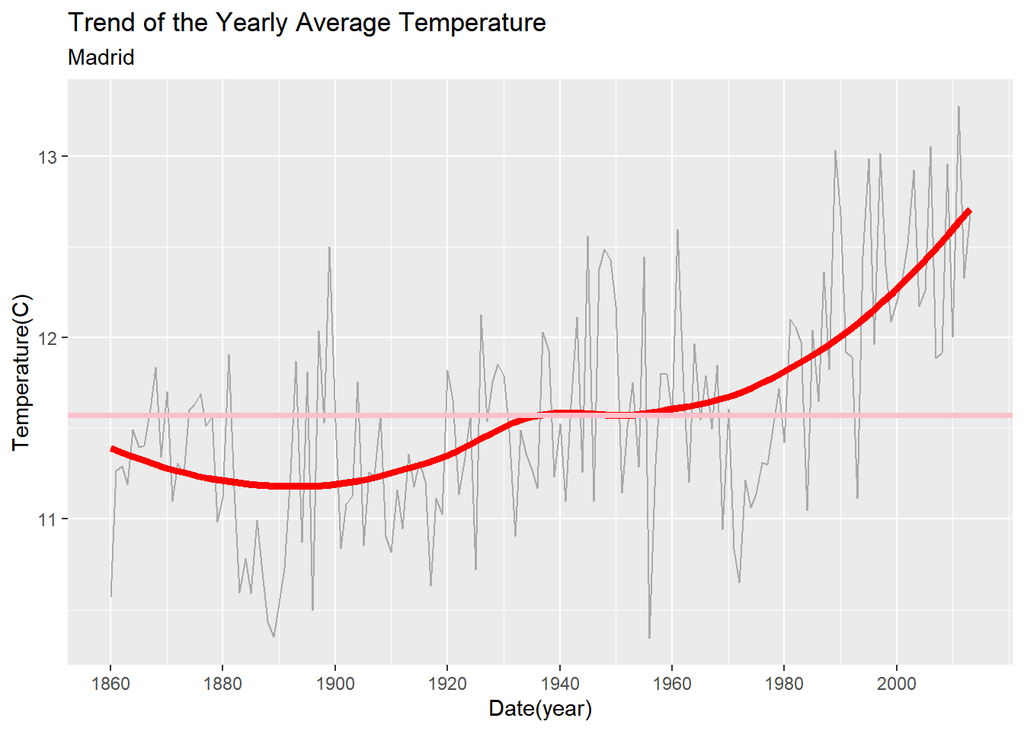

```r
#Jaehyun Song

city <- yclean %>% filter(City=="Madrid") %>% na.omit()

city %>% group_by(year) %>% summarise(ave = mean(AverageTemperature)) %>% na.omit() %>%
  ggplot() + geom_line(col="dark grey") + aes(x=year, y=ave) + geom_smooth(col='Red', se=F, lwd=1.7)+
  geom_hline(yintercept=mean(city$AverageTemperature), col='pink', lwd=1.3)+
  labs(title = "Trend of the Yearly Average Temperature", subtitle="Madrid", x= "Date(year)", y="Temperature(C)")+
  scale_x_continuous(breaks = seq(1860, 2013, 20))
```

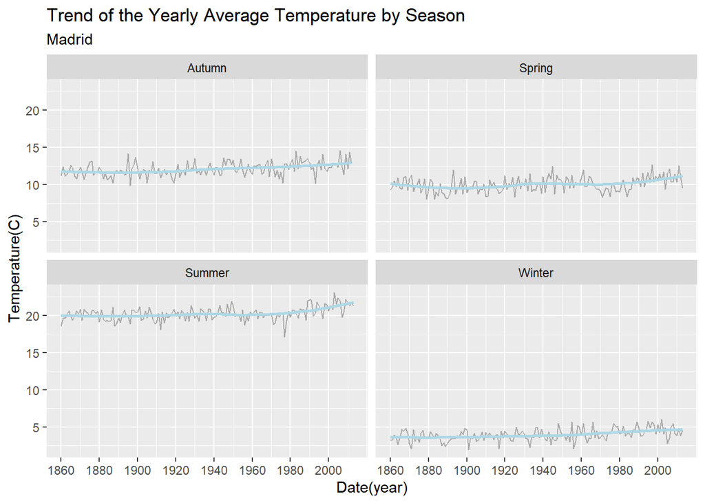

```r
city %>% group_by(season, year) %>% summarise(ave = mean(AverageTemperature)) %>% na.omit() %>%
  ggplot() + geom_line(col="dark grey") + aes(x=year, y=ave) + geom_smooth(col='light blue', se=F)+
  labs(title = "Trend of the Yearly Average Temperature by Season", subtitle="Madrid", x= "Date(year)", y="Temperature(C)")+
  scale_x_continuous(breaks = seq(1860, 2013, 20))+
  facet_wrap(~season)
```

```r
#The maximum and minimum values differ by 2.93 degrees, and during the period, they rose by 1 degree. Industrialization has occurred since the 1850s. If you look at the actual graph, not the trend line, it rise until the 1880s. By 1950, however, Spain did not continue its industrialization because inequality fluctuated and real income remained virtually stagnant, resulting in a decline.
```

# Oceania

# Oceania-Cities that change of the temperature is not significant

#3-6 Sydney

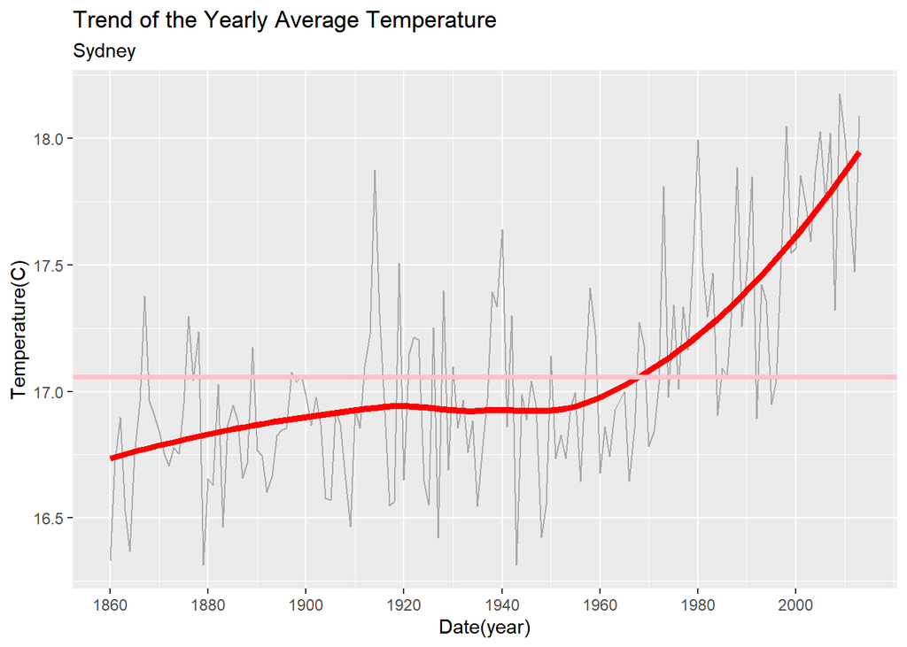

```r
#Jaehyun Song

city <- yclean %>% filter(City=="Sydney") %>% na.omit()

city %>% group_by(year) %>% summarise(ave = mean(AverageTemperature)) %>% na.omit() %>%
  ggplot() + geom_line(col="dark grey") + aes(x=year, y=ave) + geom_smooth(col='Red', se=F, lwd=1.7)+
  geom_hline(yintercept=mean(city$AverageTemperature), col='pink', lwd=1.3)+
  labs(title = "Trend of the Yearly Average Temperature", subtitle="Sydney", x= "Date(year)", y="Temperature(C)")+
  scale_x_continuous(breaks = seq(1860, 2013, 20))
```

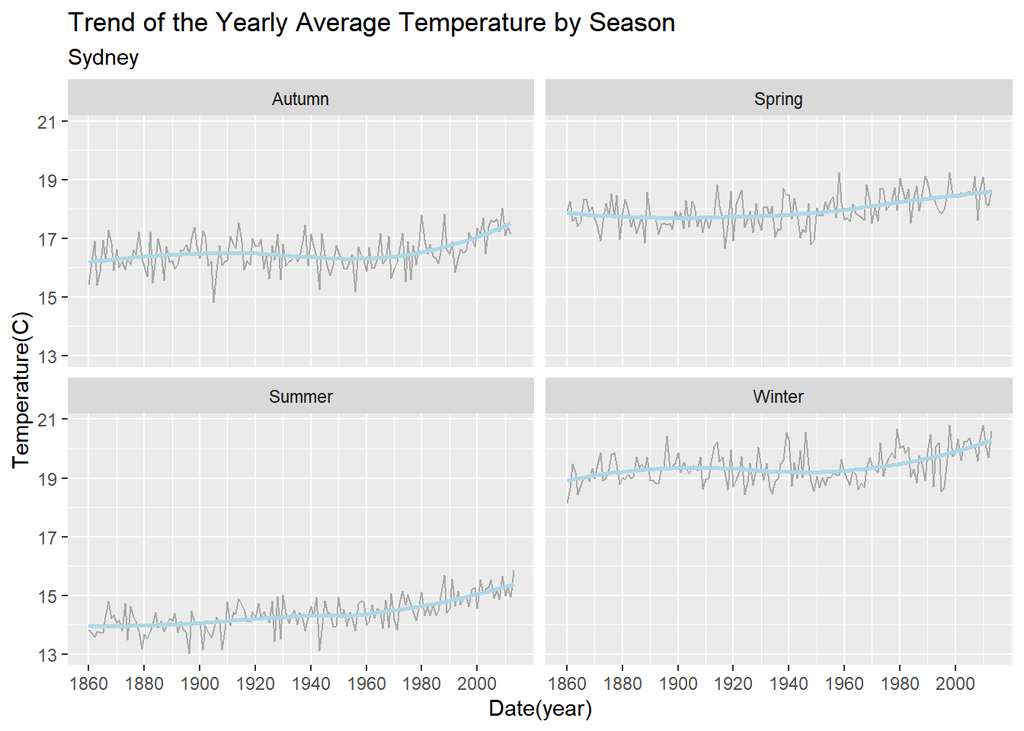

```r
city %>% group_by(season, year) %>% summarise(ave = mean(AverageTemperature)) %>% na.omit() %>%
  ggplot() + geom_line(col="dark grey") + aes(x=year, y=ave) + geom_smooth(col='light blue', se=F)+
  labs(title = "Trend of the Yearly Average Temperature by Season", subtitle="Sydney", x= "Date(year)", y="Temperature(C)")+
  scale_x_continuous(breaks = seq(1860, 2013, 20))+
  facet_wrap(~season)
```

```r
#Sydney has difference of 1.86 degrees. During this period, temperature rise up by 1 degree. Australia has been industrialized since the 1910s. Sydney and Melbourne are so close together that they are called Australia's three largest cities. So the two graphs are showing similar trends. Since 1910, the temperature has been minimal, but there has been an increase. However, the growth rate is difficult to see at a glance because the development is slower than in the Northern Hemisphere.The difference in the maximum minimum is the error caused by a big difference in the minimum value at that time, since Melbourne's temperature dropped slightly more during the Earth's waste season.
```

#3-7 Melbourne

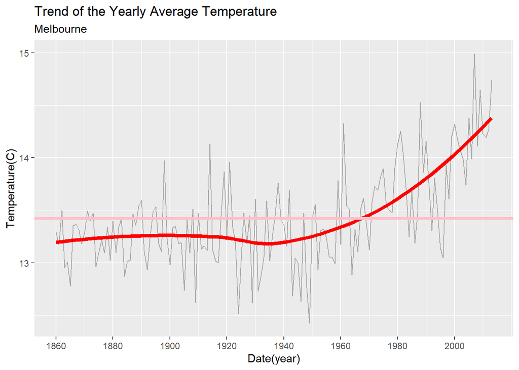

```r
#Jaehyun Song

city <- yclean %>% filter(City=="Melbourne") %>% na.omit()

city %>% group_by(year) %>% summarise(ave = mean(AverageTemperature)) %>% na.omit() %>%
  ggplot() + geom_line(col="dark grey") + aes(x=year, y=ave) + geom_smooth(col='Red', se=F, lwd=1.7)+
  geom_hline(yintercept=mean(city$AverageTemperature), col='pink', lwd=1.3)+
  labs(title = "Trend of the Yearly Average Temperature", subtitle="Melbourne", x= "Date(year)", y="Temperature(C)")+
  scale_x_continuous(breaks = seq(1860, 2013, 20))
```

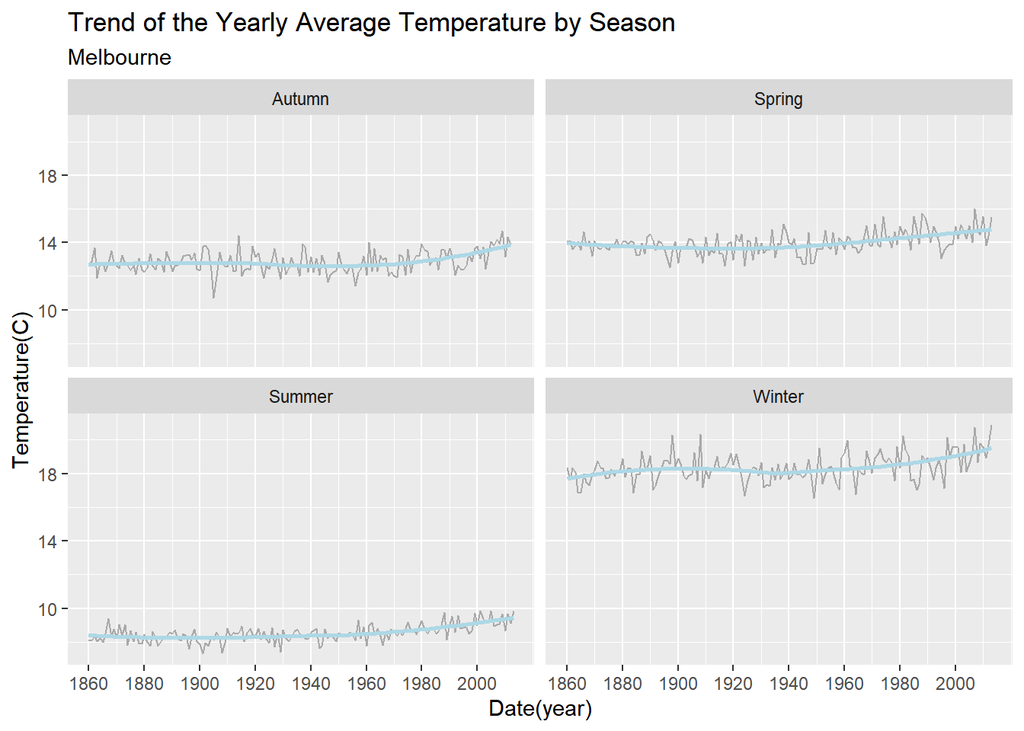

```r
city %>% group_by(season, year) %>% summarise(ave = mean(AverageTemperature)) %>% na.omit() %>%
  ggplot() + geom_line(col="dark grey") + aes(x=year, y=ave) + geom_smooth(col='light blue', se=F)+
  labs(title = "Trend of the Yearly Average Temperature by Season", subtitle="Melbourne", x= "Date(year)", y="Temperature(C)")+
  scale_x_continuous(breaks = seq(1860, 2013, 20))+
  facet_wrap(~season)
```

```r
#The difference is 2.57 degree. Temperature rose 1.5 degree during the period.
```

#Asia Continent

#Aisa-Cities that change of the temperature is significant

#3-8 Iran-Mashhad (overall graph of Mashhad’s temperature from 1860 to 2013)

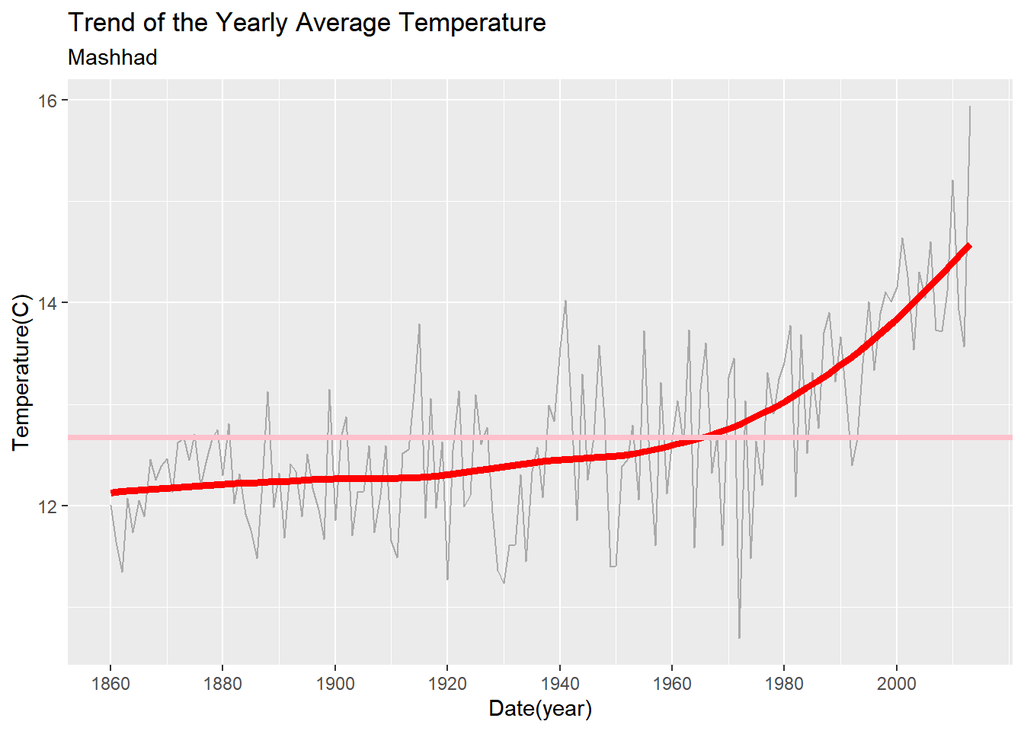

```r
#Kim Yerin
#Extract only Mashhad temperature data from 'yclean' and remove NA values
Mashhad <- yclean %>% filter(City=="Mashhad") %>% na.omit()

#Summarise annual average temperature and make a graph of it.
#Set the graph's x value for year and y value for temperature.
#Dark grey line represents the annual average temperature of Mashhad, pink line shows average temperature throughout the period(1860~2013), and red line is the reference line of the annual average temperature.
Mashhad %>% group_by(year) %>% summarise(ave = mean(AverageTemperature)) %>% na.omit() %>%
  ggplot() + geom_line(col="dark grey") + aes(x=year, y=ave) + geom_smooth(col='Red', se=F, lwd=1.7)+
  geom_hline(yintercept=mean(Mashhad$AverageTemperature), col='pink', lwd=1.3)+
  labs(title = "Trend of the Yearly Average Temperature", subtitle="Mashhad", x= "Date(year)", y="Temperature(C)")+
  scale_x_continuous(breaks = seq(1860, 2013, 20))
```

1)Analyzing the graph: Since 1965, the slope of the regression line rises rapidly.

2)Data survey about Masshad: Masshad was industrialized in 1970s. After World War II, Iran implemented strong reform policies such as nationalization of the oil industry in 1951 and the white revolution in 1962 that confiscated land from religious foundations and distributed it to farmers. In the 1970s, economic growth was achieved with full-scale industrialization. The reason for the increasing of temperature until these days is that Iran, as OPEC’s second-largest oil producer and oil exporter, which accounts for 10 percent of the world’s oil reserves, has seen much urbanization today based on economic growth.

#Iran-Mashhad (temperature graph by season)

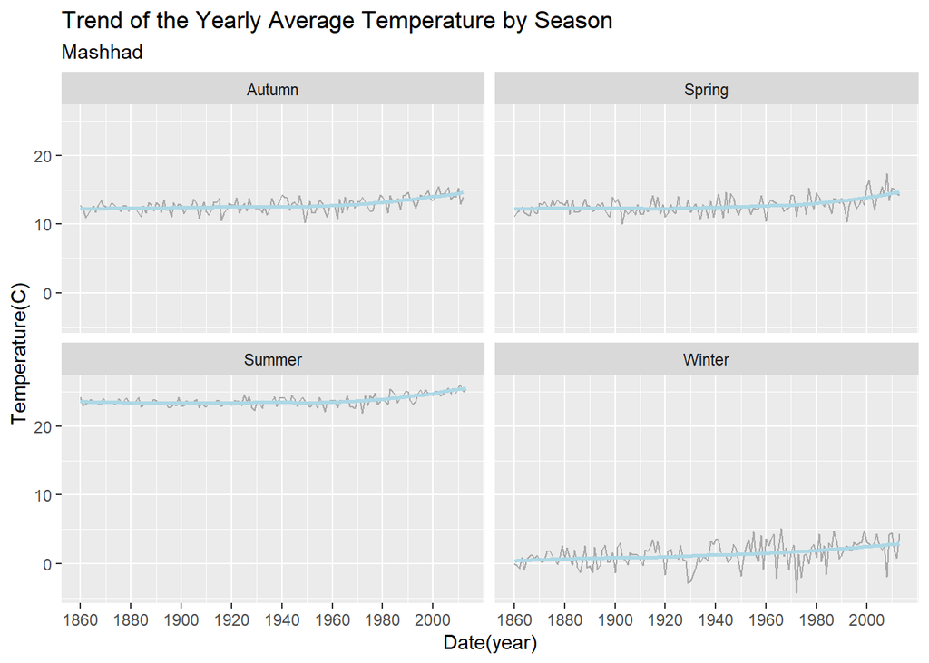

```r
#Kim Yerin
#Similar graph with above, also set the x value for year and y value for temperature, but faceted with seasons (3~5: Spring, 6~8: Summer, 9~11: Autumn, 12~2: Winter)
Mashhad %>% group_by(season, year) %>% summarise(ave = mean(AverageTemperature)) %>% na.omit() %>%
  ggplot() + geom_line(col="dark grey") + aes(x=year, y=ave) + geom_smooth(col='light blue', se=F)+
  labs(title = "Trend of the Yearly Average Temperature by Season", subtitle="Mashhad", x= "Date(year)", y="Temperature(C)")+
  scale_x_continuous(breaks = seq(1860, 2013, 20))+
  facet_wrap(~season)
```

#3-9 China-Harbin (overall graph of Harbin’s temperature from 1860 to 2013)

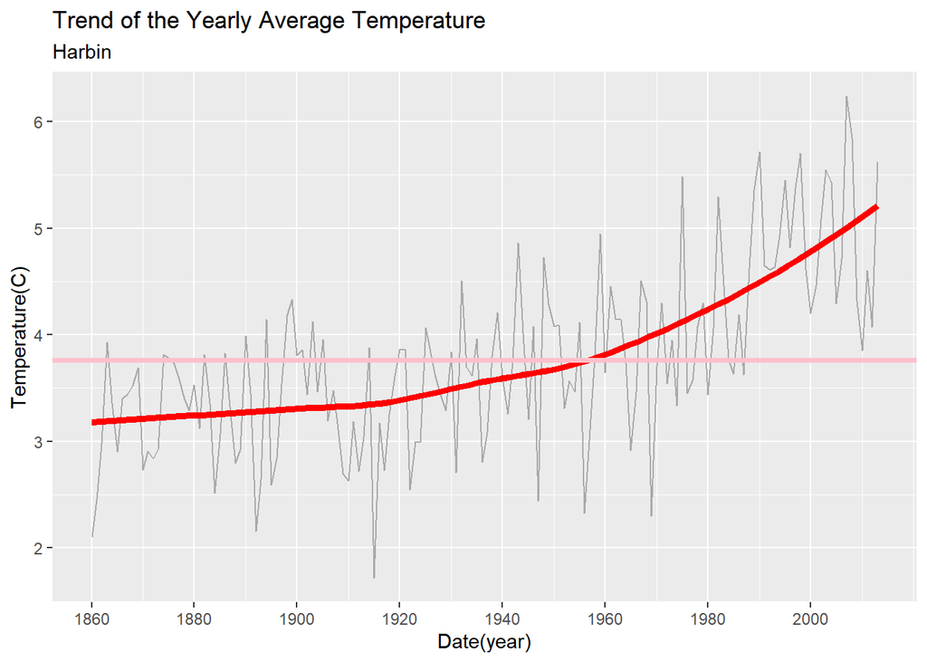

```r
#Kim Yerin
#Extract only Harbin temperature data from 'yclean' and remove NA values
Harbin <- yclean %>% filter(City=="Harbin") %>% na.omit()

#Summarise annual average temperature and make a graph of it.
#Set the graph's x value for year and y value for temperature.
#Dark grey line represents the annual average temperature of Harbin, pink line shows average temperature throughout the period(1860~2013), and red line is the reference line of the annual average temperature.
Harbin %>% group_by(year) %>% summarise(ave = mean(AverageTemperature)) %>% na.omit() %>%
  ggplot() + geom_line(col="dark grey") + aes(x=year, y=ave) + geom_smooth(col='Red', se=F, lwd=1.7)+
  geom_hline(yintercept=mean(Harbin$AverageTemperature), col='pink', lwd=1.3)+
  labs(title = "Trend of the Yearly Average Temperature", subtitle="Harbin", x= "Date(year)", y="Temperature(C)")+
  scale_x_continuous(breaks = seq(1860, 2013, 20))
```

1)Analyzing the graph: Since 1955, the slope of the regression line rises rapidly.

2)Data survey about Harbin: In Harbin, industrialized started in 1950s and grew in earnest in the late 1970s. After World War II, Harbin’s sovereignty was transferred to China in 1946, and many economic reforms began. But the economy growth became falters since 1950, when Mao Zedong failed to reform the economy and a great famine due to them. It was 1976 when Deng Xiaoping led the economic growth in earnest as the standard of living improved and the food shortage eased due to reforms such as giving farmers freedom to cultivate their own farmland. With the recovery of U.S.-China diplomatic relations in 1979, reform and opening-up of accepting foreign capital began, and huge foreign capital flowed in thanks to China’s cheap labor and rent, resulting in economic growth.

#China-Harbin (temperature graph by season)

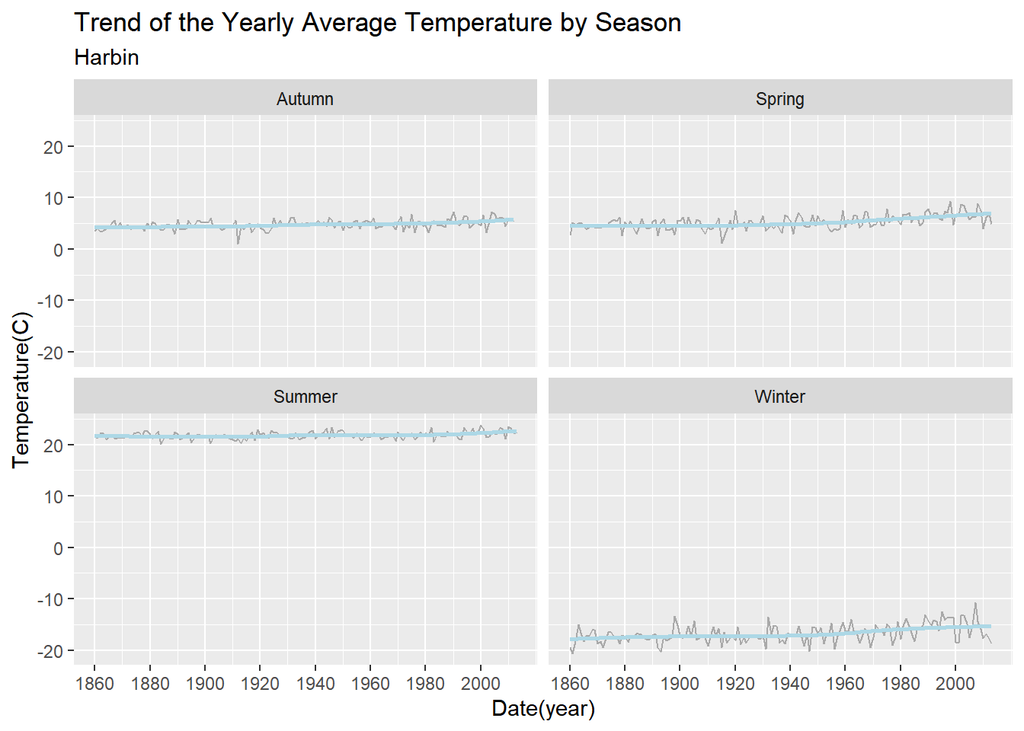

```r
#Kim Yerin
#Similar graph with above, also set the x value for year and y value for temperature, but faceted with seasons (3~5: Spring, 6~8: Summer, 9~11: Autumn, 12~2: Winter)
Harbin %>% group_by(season, year) %>% summarise(ave = mean(AverageTemperature)) %>% na.omit() %>%
  ggplot() + geom_line(col="dark grey") + aes(x=year, y=ave) + geom_smooth(col='light blue', se=F)+
  labs(title = "Trend of the Yearly Average Temperature by Season", subtitle="Harbin", x= "Date(year)", y="Temperature(C)")+
  scale_x_continuous(breaks = seq(1860, 2013, 20))+
  facet_wrap(~season)
```

#3-10 China-Shanghai (overall graph of Shanghai’s temperature from 1860 to 2013)

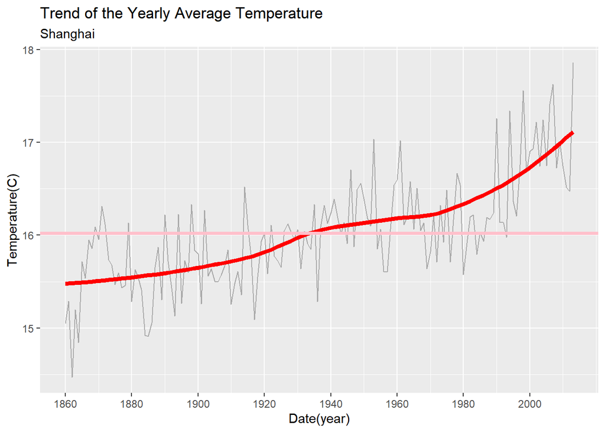

```r
#Kim Yerin
#Extract only Shanghai temperature data from 'yclean' and remove NA values
Shanghai <- yclean %>% filter(City=="Shanghai") %>% na.omit()

#Summarise annual average temperature and make a graph of it.
#Set the graph's x value for year and y value for temperature.
#Dark grey line represents the annual average temperature of Shanghai, pink line shows average temperature throughout the period(1860~2013), and red line is the reference line of the annual average temperature.
Shanghai %>% group_by(year) %>% summarise(ave = mean(AverageTemperature)) %>% na.omit() %>%
  ggplot() + geom_line(col="dark grey") + aes(x=year, y=ave) + geom_smooth(col='Red', se=F, lwd=1.7)+
  geom_hline(yintercept=mean(Shanghai$AverageTemperature), col='pink', lwd=1.3)+
  labs(title = "Trend of the Yearly Average Temperature", subtitle="Shanghai", x= "Date(year)", y="Temperature(C)")+
  scale_x_continuous(breaks = seq(1860, 2013, 20))
```

1)Analyzing the graph: The graph slowed down around the 1950s, but showed a rapid rise once again as it entered the 1990s.

#China-Shanghai (temperature graph by season)

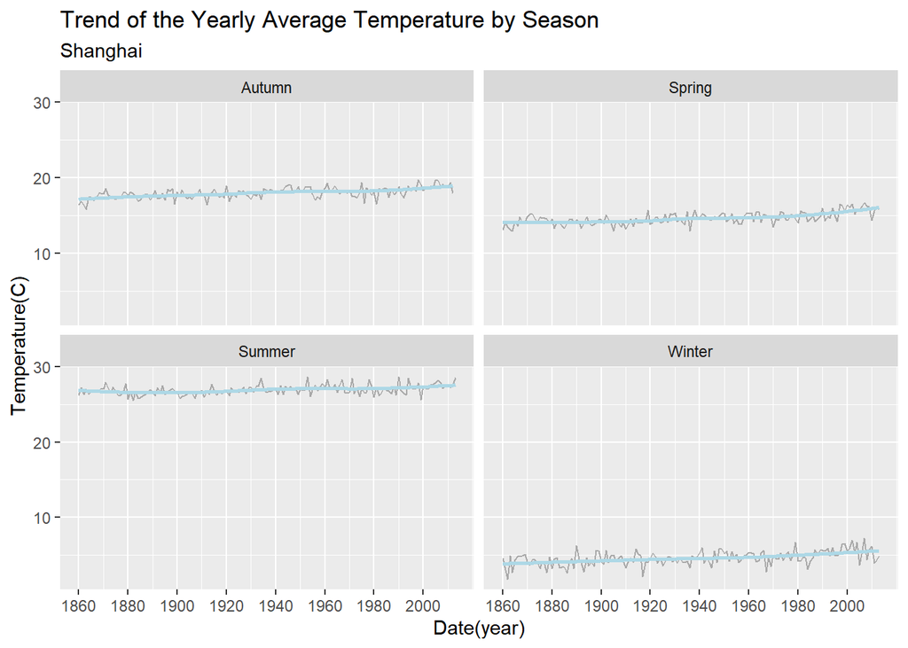

```r
#Kim Yerin
#Similar graph with above, also set the x value for year and y value for temperature, but faceted with seasons (3~5: Spring, 6~8: Summer, 9~11: Autumn, 12~2: Winter)
Shanghai %>% group_by(season, year) %>% summarise(ave = mean(AverageTemperature)) %>% na.omit() %>%
  ggplot() + geom_line(col="dark grey") + aes(x=year, y=ave) + geom_smooth(col='light blue', se=F)+
  labs(title = "Trend of the Yearly Average Temperature by Season", subtitle="Shanghai", x= "Date(year)", y="Temperature(C)")+
  scale_x_continuous(breaks = seq(1860, 2013, 20))+
  facet_wrap(~season)
```

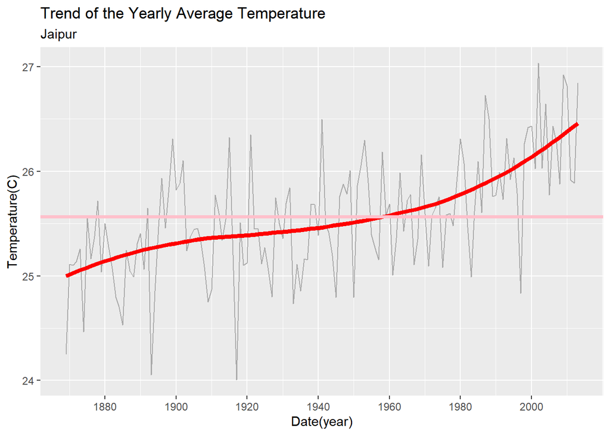

```r
#Kim Yerin
#Extract only Jaipur temperature data from 'yclean' and remove NA values
Jaipur <- yclean %>% filter(City=="Jaipur") %>% na.omit()

#Summarise annual average temperature and make a graph of it.
#Set the graph's x value for year and y value for temperature.
#Dark grey line represents the annual average temperature of Jaipur, pink line shows average temperature throughout the period(1860~2013), and red line is the reference line of the annual average temperature.
Jaipur %>% group_by(year) %>% summarise(ave = mean(AverageTemperature)) %>% na.omit() %>%
  ggplot() + geom_line(col="dark grey") + aes(x=year, y=ave) + geom_smooth(col='Red', se=F, lwd=1.7)+
  geom_hline(yintercept=mean(Jaipur$AverageTemperature), col='pink', lwd=1.3)+
  labs(title = "Trend of the Yearly Average Temperature", subtitle="Jaipur", x= "Date(year)", y="Temperature(C)")+
  scale_x_continuous(breaks = seq(1860, 2013, 20))
```

1)Analyzing the graph: Since 1960s, the slope of the regression line rises rapidly.

2)Data survey about Jaipur: Jaipur was industrialized in the 1950s. India, which was under British colonial rule, gained independence after World War II in 1950s. It succeeded in building an industrial production base and self-sufficiency in food after the 1970s by continuously pushing forward economic development plans focusing on the development of heavy industries and the solidification of agricultural production bases by focusing on the development of import replacement industries. In the 1980s, the government achieved an early stage of market opening by implementing policies for economic liberalization and opening up, including measures to liberalize foreign investment, while realizing an average annual growth of 5 percent thanks to increased oil production and economic recovery in advanced countries. In the 1990s, the government achieved full-fledged economic growth through the stages of market opening and economic liberalization under the new economic policies. Although India’s economic growth rate is relatively slow, it is still in the spotlight today as an economic powerhouse with a high potential for development due to its sophisticated systems and industrial base.

#India-Jaipur (temperature graph by season)

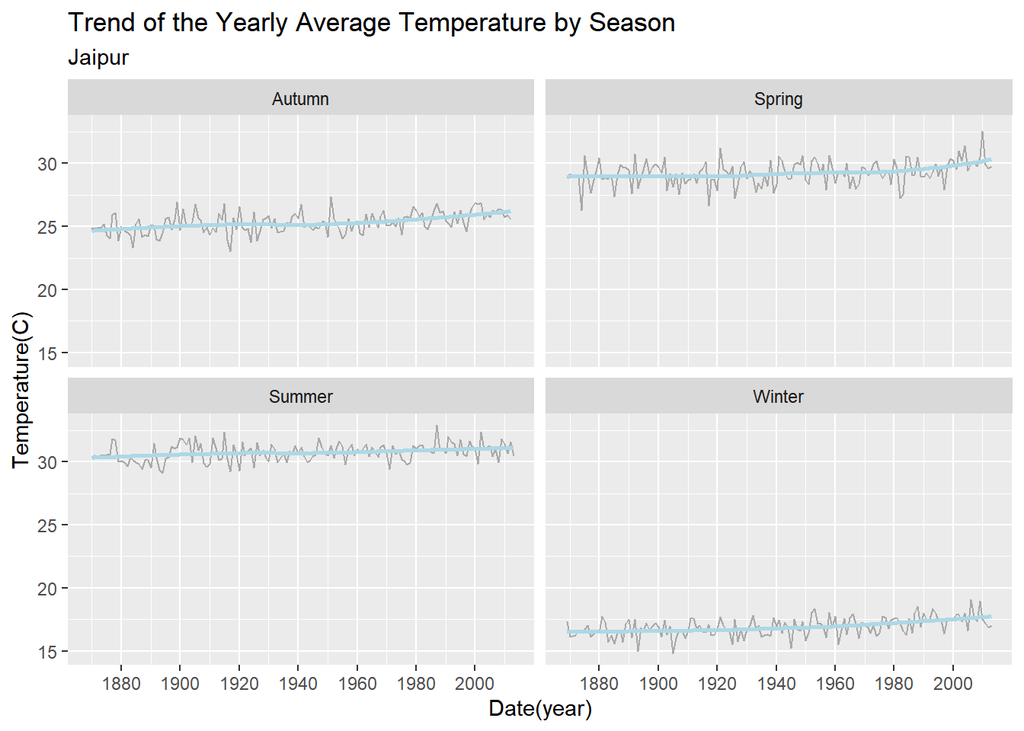

```r
#Kim Yerin
#Similar graph with above, also set the x value for year and y value for temperature, but faceted with seasons (3~5: Spring, 6~8: Summer, 9~11: Autumn, 12~2: Winter)
Jaipur %>% group_by(season, year) %>% summarise(ave = mean(AverageTemperature)) %>% na.omit() %>%
  ggplot() + geom_line(col="dark grey") + aes(x=year, y=ave) + geom_smooth(col='light blue', se=F)+
  labs(title = "Trend of the Yearly Average Temperature by Season", subtitle="Jaipur", x= "Date(year)", y="Temperature(C)")+
  scale_x_continuous(breaks = seq(1860, 2013, 20))+
  facet_wrap(~season)
```

#Aisa-Cities that change of the temperature is not significant

#3-12 India-Bangalore (overall graph of Bangalore’s temperature from 1860 to 2013)

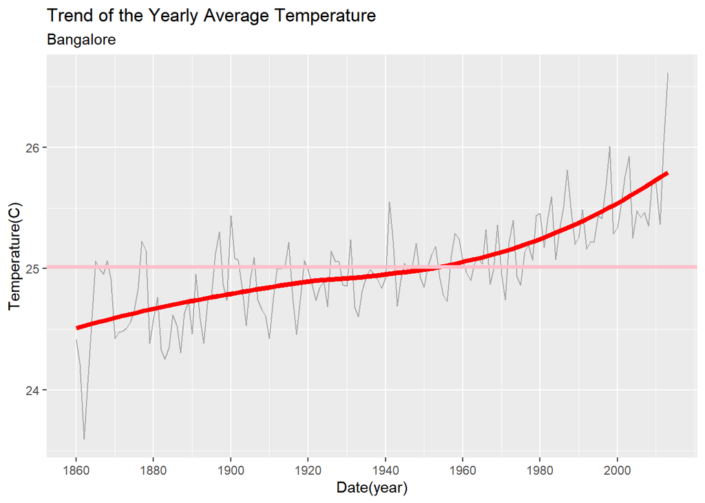

```r
#Kim Yerin
#Extract only Bangalore temperature data from 'yclean' and remove NA values
Bangalore <- yclean %>% filter(City=="Bangalore") %>% na.omit()

#Summarise annual average temperature and make a graph of it.
#Set the graph's x value for year and y value for temperature.
#Dark grey line represents the annual average temperature of Bangalore, pink line shows average temperature throughout the period(1860~2013), and red line is the reference line of the annual average temperature.
Bangalore %>% group_by(year) %>% summarise(ave = mean(AverageTemperature)) %>% na.omit() %>%
  ggplot() + geom_line(col="dark grey") + aes(x=year, y=ave) + geom_smooth(col='Red', se=F, lwd=1.7)+
  geom_hline(yintercept=mean(Bangalore$AverageTemperature), col='pink', lwd=1.3)+
  labs(title = "Trend of the Yearly Average Temperature", subtitle="Bangalore", x= "Date(year)", y="Temperature(C)")+
  scale_x_continuous(breaks = seq(1860, 2013, 20))
```

1)Analyzing the graph: Since the 1950s, the slope has become steeper than before, but overall, it shows a gentle slope.

#India-Bangalore (temperature graph by season)

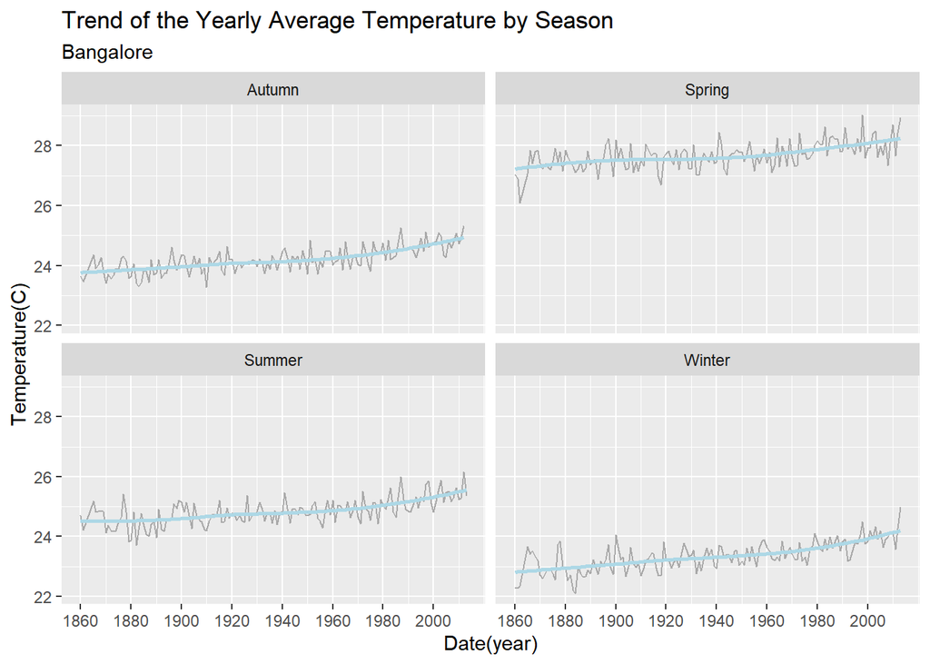

```r
#Kim Yerin
#Similar graph with above, also set the x value for year and y value for temperature, but faceted with seasons (3~5: Spring, 6~8: Summer, 9~11: Autumn, 12~2: Winter)
Bangalore %>% group_by(season, year) %>% summarise(ave = mean(AverageTemperature)) %>% na.omit() %>%
  ggplot() + geom_line(col="dark grey") + aes(x=year, y=ave) + geom_smooth(col='light blue', se=F)+
  labs(title = "Trend of the Yearly Average Temperature by Season", subtitle="Bangalore", x= "Date(year)", y="Temperature(C)")+
  scale_x_continuous(breaks = seq(1860, 2013, 20))+
  facet_wrap(~season)
```

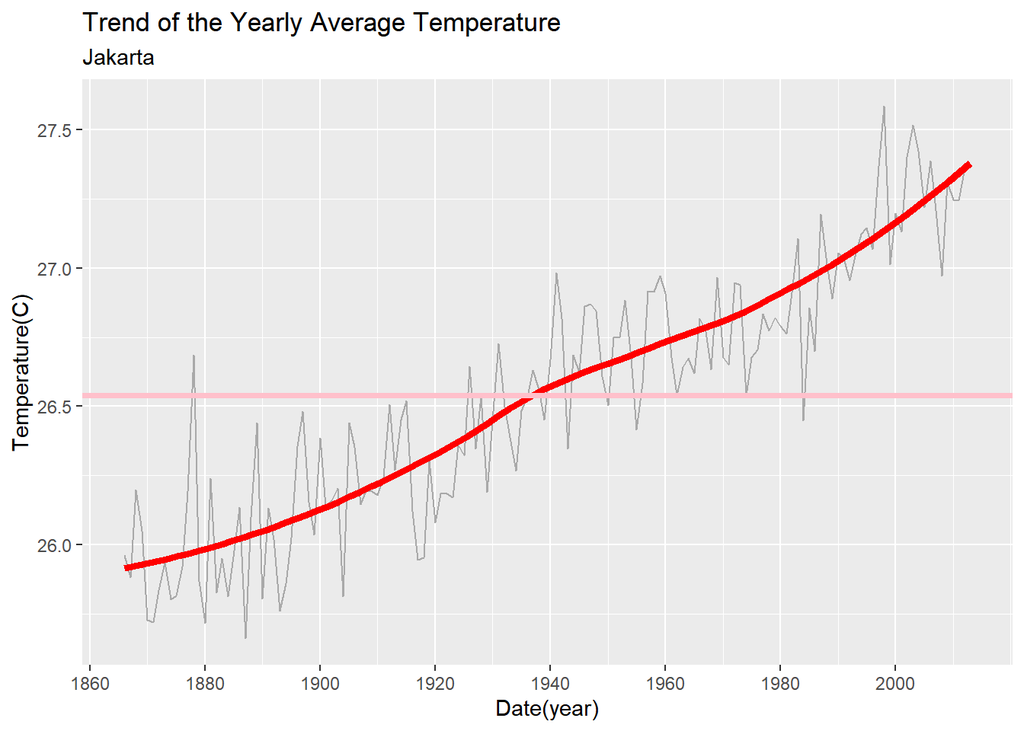

```r
#Kim Yerin
#Extract only Jakarta temperature data from 'yclean' and remove NA values
Jakarta <- yclean %>% filter(City=="Jakarta") %>% na.omit()

#Summarise annual average temperature and make a graph of it.
#Set the graph's x value for year and y value for temperature.
#Dark grey line represents the annual average temperature of Jakarta, pink line shows average temperature throughout the period(1860~2013), and red line is the reference line of the annual average temperature.
Jakarta %>% group_by(year) %>% summarise(ave = mean(AverageTemperature)) %>% na.omit() %>%
  ggplot() + geom_line(col="dark grey") + aes(x=year, y=ave) + geom_smooth(col='Red', se=F, lwd=1.7)+
  geom_hline(yintercept=mean(Jakarta$AverageTemperature), col='pink', lwd=1.3)+
  labs(title = "Trend of the Yearly Average Temperature", subtitle="Jakarta", x= "Date(year)", y="Temperature(C)")+
  scale_x_continuous(breaks = seq(1860, 2013, 20))
```

1)Analyzing the graph: Temperatures are rising at a constant slope, with the regression line on the graph close to a straight line.

2)Data survey about Jakarta: Jakarta was industrialized in the 1990s. After World War II, Indonesia, which was ruled by the Netherlands, gain independence in 1949, excessively consumed national power in political and cultural growth and inconsistency and corruption in economic policy led the fail in economic growth. Then, industrialization began in the late 1970s, but economic growth slowed due to falling crude oil prices and existing regulations in the 1980s. After then, it has achieved economic growth, but the economy has slowed again in the face of the 1997 Asian financial crisis. In these unlucky history Indonesia has no chance to achieved rapid economic development.

#Indonesia-Jakarta (temperature graph by season)

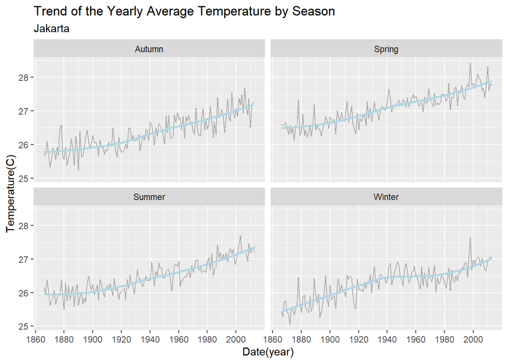

```r
#Kim Yerin
#Similar graph with above, also set the x value for year and y value for temperature, but faceted with seasons (3~5: Spring, 6~8: Summer, 9~11: Autumn, 12~2: Winter)
Jakarta %>% group_by(season, year) %>% summarise(ave = mean(AverageTemperature)) %>% na.omit() %>%
  ggplot() + geom_line(col="dark grey") + aes(x=year, y=ave) + geom_smooth(col='light blue', se=F)+
  labs(title = "Trend of the Yearly Average Temperature by Season", subtitle="Jakarta", x= "Date(year)", y="Temperature(C)")+
  scale_x_continuous(breaks = seq(1860, 2013, 20))+
  facet_wrap(~season)
```

#3-14 China-Guangzhou (overall graph of Guangzhou’s temperature from 1860 to 2013)

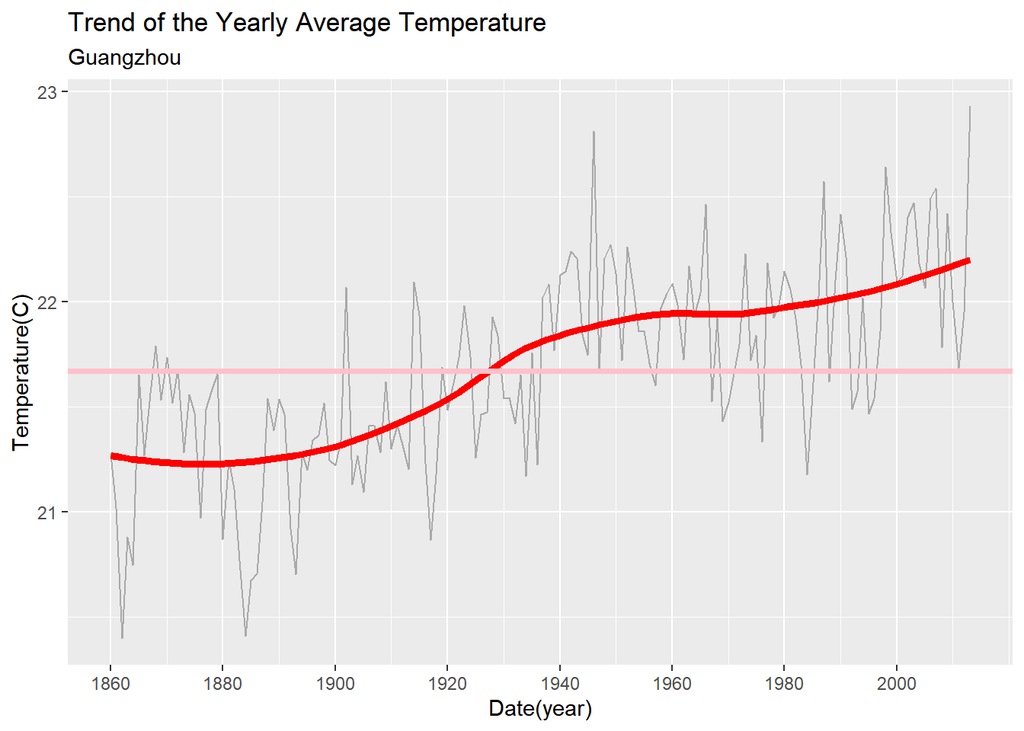

```r
#Kim Yerin
#Extract only Guangzhou temperature data from 'yclean' and remove NA values
Guangzhou <- yclean %>% filter(City=="Guangzhou") %>% na.omit()

#Summarise annual average temperature and make a graph of it.
#Set the graph's x value for year and y value for temperature.
#Dark grey line represents the annual average temperature of Guangzhou, pink line shows average temperature throughout the period(1860~2013), and red line is the reference line of the annual average temperature.
Guangzhou %>% group_by(year) %>% summarise(ave = mean(AverageTemperature)) %>% na.omit() %>%
  ggplot() + geom_line(col="dark grey") + aes(x=year, y=ave) + geom_smooth(col='Red', se=F, lwd=1.7)+
  geom_hline(yintercept=mean(Guangzhou$AverageTemperature), col='pink', lwd=1.3)+
  labs(title = "Trend of the Yearly Average Temperature", subtitle="Guangzhou", x= "Date(year)", y="Temperature(C)")+
  scale_x_continuous(breaks = seq(1860, 2013, 20))
```

1)Analyzing the graph: From 1950 to 1980, the slope of the graph is gentle and there is not much increase overall.

#China-Guangzhou (temperature graph by season)

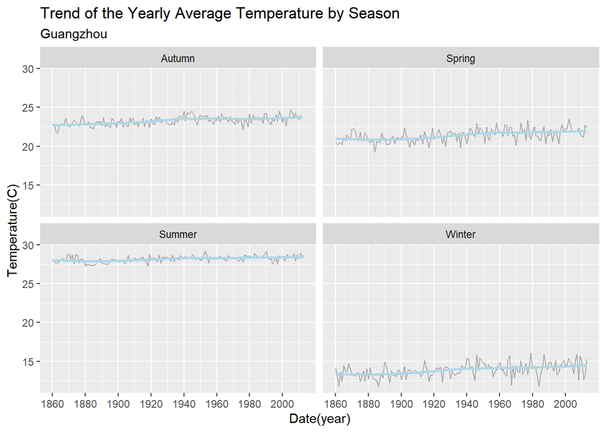

```r
#Kim Yerin
#Similar graph with above, also set the x value for year and y value for temperature, but faceted with seasons (3~5: Spring, 6~8: Summer, 9~11: Autumn, 12~2: Winter)
Guangzhou %>% group_by(season, year) %>% summarise(ave = mean(AverageTemperature)) %>% na.omit() %>%
  ggplot() + geom_line(col="dark grey") + aes(x=year, y=ave) + geom_smooth(col='light blue', se=F)+
  labs(title = "Trend of the Yearly Average Temperature by Season", subtitle="Guangzhou", x= "Date(year)", y="Temperature(C)")+
  scale_x_continuous(breaks = seq(1860, 2013, 20))+
  facet_wrap(~season)
```